# Binary Logistic Rgresssion

TU059 - Task 2 - Binary Logistic Rgresssion

Author

Student Number: D24127620, Student Name: Eamonn Kelly, Programme Code: TU059

```r
#
# Define variables that we want to use in or analysis
# we'll craete a subset of the data with just those to keep our dataset as light as we can.
varsint <- c("waterbodyname",  "years",  "sampledate",  "alkalinity.total..as.caco3.",  "bod...5.days..total.", "ammonia.total..as.n.", "chloride", "conductivity..25.c",  "dissolved.oxygen",  "ph",  "temperature",  "total.hardness..as.caco3.", "true.colour", "ccme_wqi",  "wawqi",  "horton.wqi",  "brown.wqi",  "srdd.wqi")

# create data subset of variables we want to lok at
wqi_dsubset <- wqi_df[varsint]


#  human friendly labels
colnames(wqi_dsubset) <- c( "waterbodyname", "years", "month", "alkalinity",  "biochem_ox_dmnd", "ammonia", "chloride", "conductivity", "dissolved.oxygen", "ph",  "temperature", "hardness", "colour", "ccme_wqi",  "wawqi",  "horton.wqi",  "brown.wqi",  "srdd.wqi")
```

# 1. Introduction

This analysis will perform a binary logistic regression to predict water quality, using historical water quality data which was taken over a period of 16 years from 2007 to 2023 across 16 locations in Ireland by the **Environmental Protection Agency (EPA)**. The data was then used to classify water quality at these locations. The data set was sourced from the following location [Water Quality Monitoring Dataset (Ireland)](https://figshare.com/articles/dataset/Water_Quality_Monitoring_Dataset_Ireland_/25002131), and is a merging of multiple csv files from the **EPA** into a single source.

Water samples were taken from 160 sites within these 16 geographical areas, at various times throughout the year, tested in labs, and calculations were then carried out to determine Water Quality according to different water quality standards, a number of which exist.

## 1.1 Project Overview

The project will create a categorical binary variable in our dataset and build a binary logistic regression model which will evaluate the predictive power of key water quality classifying paramaters, namely **Dissolved Oxygen (DO)**, **Temperature** and **ph**. The model will be able to predict whether a sample set of data take’ from a water source is of ‘good’ or ‘poor’ quality, based on the historical data in our dataset This boolean variable, indicating ‘good’ or ’poor water quality, **wqi_bool**, will be our **outcome** variable.

**Predictor Variables**:

- **dissolved oxygen (DO)**: a key water quality measurable providing the amount of oxygen present in water and therefore its ability to support life. We expect to see that the more dissolved oxygen is present, the better the water quality.
- **temperature**: influences how soluble substances are within water, including oxygen and organic matter. This will also affect the rate of biochemical reactions at higher and lower extremes.
- **ph**: acidity / alkaline indicator which affects support for various processes, both chemical and organic. Similar to temperature we expect to see poorer water quality at higher and lower extremes.

Note: Other predictor variables were considered, specifically Biochemical **Oxygen Demand(BOD)**, however there is strong co-linearity between it and some of the existing predictors, such as **Dissolved Oxygen (DO)**, as such to avoid potential issues in our model assumptions at a later stage,it was decided to leave it out and keep our number of variables to a minimum as much as possible. Also, we have used these as predictors in our previous assignment as they are particularly relevant in determining water quality and provide us with level of intepretability i.e. we can mor easily understand their effects, although there are many other variables involved in determining water quality. Using them again here however may be able to provide further insight into them, their relationships and predictive value.

## 1.2 Hypothesis

**H3 - Hypothesis**: **dissolved oxygen**, **temperature** and **ph** combined, as water quality metrics, can provide a statistically significant binary logistic regression predictive model, allowing for the classification of water quality outcomes as ‘good’ or ‘poor’.

## 1.3 Statistical assumptions and Diagnostics

Throughout the analysis, a significance threshold of 0.05 was used, and effect sizes were reported according to Cohen’s conventions(1988).

# 2. Data description and preparation

## 2.1 Overview

The dataset contains ‘29,159’ rows and ‘18’ variables typically included in water quality analysis such as **ph**, **temperature**, **biochemical oxygen demand *BOD**,** dissolved oxygen**,** alkalinity** and others. The concepts of interest, their measurement and statistical type are shown in Tables 1 and 2 below.

| variable | r_type | is_factor | factor_summary |
| --- | --- | --- | --- |
| waterbodyname | factor | TRUE | 160 levels (e.g., ABBEYTOWN_010, Allua,) |
| years | integer | FALSE | NA |
| month | factor | TRUE | 12 levels (e.g., Jan, Feb, …) |
| alkalinity | double | FALSE | NA |
| biochem_ox_dmnd | double | FALSE | NA |
| ammonia | double | FALSE | NA |
| chloride | double | FALSE | NA |
| conductivity | double | FALSE | NA |
| dissolved.oxygen | double | FALSE | NA |
| ph | double | FALSE | NA |
| temperature | double | FALSE | NA |
| hardness | double | FALSE | NA |
| colour | double | FALSE | NA |
| ccme_wqi | factor | TRUE | 5 levels (e.g., Excellent, Fair, …) |
| wawqi | factor | TRUE | 6 levels (e.g., Excellent, Fair, …) |
| horton.wqi | factor | TRUE | 6 levels (e.g., Excellent, Fair, …) |
| brown.wqi | factor | TRUE | 5 levels (e.g., Excellent, Fair, …) |
| srdd.wqi | factor | TRUE | 6 levels (e.g., Excellent, Fair, …) |

Table 1. Variable and Statistical Datatypes present in the data set

Note the presence of several WQI categorical variables.These are water quality metrics form difference classification standards, of which there are a few. We will not use these as part of our multiple linear regression model.

We will create a reduced dataset to include primarily just the variables required for our two models, namely, **month**, **dissolved.oxygen**, **ph** and **temperature**.

| Variable | Range (Min–Max) | Mean | SD | Median | IQR (1st Qu. - 3rd Qu |
| --- | --- | --- | --- | --- | --- |
| **Dissolved Oxygen (% sat)** | 0–198 | 58.29 | 22.5 | 54.9 | 49.4–75.0 |
| **pH** | 4.7–9.8 | 7.55 | 0.7 | 7.7 | 7.2–8.0 |
| **Temperature (°C)** | 0.6–637.0* | 10.85 | 2.5 | 10.7 | 8.2–13.1 |

Table 2. Continuous (Interval/Ratio) Data Descriptions

Detailed analysis of our data was performed in the previous assignment phase 1, and is available for viewing there. We will not include all of that here. Rather we will include some of the most relevant points, and any additional analysis where it is felt it is required.

**Some General observations:**

- **dissolved oxygen (DO)** - is % saturation level of oxygen in the water. Is a ratio of the actual amount of dissolved oxygen relative to maximum amount that could be dissolved. It can be supersaturated, i.e. > 100%, and have very excessive values of oxygen saturation. This is the reason for its spread in our data, as per the table above. Other water oxygen metrics have a much narrower range.
- **ph** - mean values, a narrow spread, which is as expected.
- **Temperature (°C)** - data ranges from just above freezing and 3rd quantile approx 13 C. There are some outliers present here.

Visual inspection of the histograms and Q–Q plots for all predictor and outcome variables were preformed in assignment 1. The standardized scores for skewness and kurtosis, as well as the percentages of absolute z-scores exceeding ±3.29, were inspected.

## 2.2 Address temperature Outliers and BOD skewness in dataframe

```r
# Temperature variable -  delete these rows with temperature valeus > 40 degrees Celsius
wqi_dsubset_clean_t <- wqi_dsubset %>% filter(temperature <= 40 | is.na(temperature))

# Biochemical Oxygen Demand (BOD) variable -  transform to the 'log10' to address
wqi_dsubset_clean_t_bod <- wqi_dsubset_clean_t %>%
  # add +1 to handle zeros safely and rename the variables
  mutate(bod_log10 = log10(biochem_ox_dmnd + 1))
summary(wqi_dsubset_clean_t_bod)
```

```
 waterbodyname          years         month             alkalinity
 Length:29154       Min.   :2007   Length:29154       Min.   :  0.0
 Class :character   1st Qu.:2011   Class :character   1st Qu.: 55.0
 Mode  :character   Median :2015   Mode  :character   Median :127.0
                    Mean   :2015                      Mean   :139.9
                    3rd Qu.:2018                      3rd Qu.:214.0
                    Max.   :2023                      Max.   :442.0
 biochem_ox_dmnd     ammonia            chloride        conductivity
 Min.   : 0.000   Min.   : 0.00000   Min.   :   0.00   Min.   :  33
 1st Qu.: 1.200   1st Qu.: 0.03300   1st Qu.:  15.60   1st Qu.: 229
 Median : 1.200   Median : 0.03300   Median :  18.60   Median : 356
 Mean   : 1.277   Mean   : 0.06358   Mean   :  20.26   Mean   : 363
 3rd Qu.: 1.200   3rd Qu.: 0.03300   3rd Qu.:  22.00   3rd Qu.: 501
 Max.   :16.000   Max.   :40.00000   Max.   :1260.00   Max.   :4200
 dissolved.oxygen       ph         temperature       hardness
 Min.   :  0.00   Min.   :4.700   Min.   : 0.60   Min.   :  0.0
 1st Qu.: 49.40   1st Qu.:7.200   1st Qu.: 8.20   1st Qu.: 71.0
 Median : 54.90   Median :7.700   Median :10.70   Median :152.0
 Mean   : 58.29   Mean   :7.552   Mean   :10.82   Mean   :159.1
 3rd Qu.: 75.00   3rd Qu.:8.000   3rd Qu.:13.10   3rd Qu.:237.0
 Max.   :198.00   Max.   :9.800   Max.   :27.40   Max.   :642.0
     colour         ccme_wqi            wawqi            horton.wqi
 Min.   :  0.00   Length:29154       Length:29154       Length:29154
 1st Qu.: 25.00   Class :character   Class :character   Class :character
 Median : 45.00   Mode  :character   Mode  :character   Mode  :character
 Mean   : 58.14
 3rd Qu.: 74.00
 Max.   :953.00
  brown.wqi           srdd.wqi           bod_log10
 Length:29154       Length:29154       Min.   :0.0000
 Class :character   Class :character   1st Qu.:0.3424
 Mode  :character   Mode  :character   Median :0.3424
                                       Mean   :0.3497
                                       3rd Qu.:0.3424
                                       Max.   :1.2304
```

## 2.3 Create Binary Water Quality Variable from Existing WQI indices

There is a large variety of water quality standards used internationally. Below is a table of classification systems and how the same data for our dataset is classified across each of them.

```r
wqi_working_df <- wqi_dsubset_clean_t_bod
# craete alist of unique values for the wqi classifiers to
wqi_classifiers <- list(
  CCME_WQI   = sort(unique(wqi_working_df$ccme_wqi)),
  WAWQI      = sort(unique(wqi_working_df$wawqi)),
  Horton_WQI = sort(unique(wqi_working_df$horton.wqi)),
  Brown_WQI  = sort(unique(wqi_working_df$brown.wqi)),
  SRDD_WQI   = sort(unique(wqi_working_df$srdd.wqi))
)
# display the list
wqi_classifiers
```

```
$CCME_WQI
[1] "Excellent" "Fair"      "Good"      "Moderate"  "Poor"

$WAWQI
[1] "Excellent"  "Fair"       "Good"       "Moderate"   "Poor"
[6] "Unsuitable"

$Horton_WQI
[1] "Excellent"  "Fair"       "Good"       "Moderate"   "Poor"
[6] "Unsuitable"

$Brown_WQI
[1] "Excellent" "Fair"      "Good"      "Moderate"

$SRDD_WQI
[1] "Excellent"  "Fair"       "Good"       "Moderate"   "Poor"
[6] "Unsuitable"
```

Below is table of some general observations of the spread across each classifier

| Observation | Interpretation |
| --- | --- |
| **CCME_WQI** |  |
| **WAWQI** | Most values classified as**“Good”** and even spread for others. |
| **Brown_WQI** | Most values classified as**“Good”** and then **Excellent**. |
| **Horton_WQI** | Fairly even classification |
| **SRDD_WQI** | Even distribution across top 3 to 4 categories |

Table 4. Water Quality Classification model general observations

After some additional investigation, we will continue to use **CCME_WQI** from our dataset, as it is used widely as an international standard. The **ccme** defined classification standards are as outlined at [Canadian Water Quality Guidelines for the Protection of Aquatic Life](https://ccme.ca/en/res/wqimanualen.pdf).

Which is based on this WQI value, water quality is classified into one of five ranks: Excellent (95–100), Good (80–94), Fair (65–79), Marginal (45–64), and Poor (0–44)

The following table displays the current values associated with all the **CCME WQI** classification metrics in our dataset

```r
# value count for the existing ccme wqi classification values
wqi_working_df %>% dplyr::count(ccme_wqi)
```

```
   ccme_wqi     n
1 Excellent   154
2      Fair 17355
3      Good  5117
4  Moderate  6451
5      Poor    77
```

It was decided to use this **CME WQI** classification to derive the binary outcome variable **wqi_bool**, and not to include **CME WQI** as a predictor in the regression model.

To create a binary categorical variable we can use in our logistic regression model, we will sub-classify these into a new variable, called **wqi_bool**, with boolean values as follows:

- ‘1’ = “Excellent” and **Good”
- ‘0’ = “Fair”, “Marginal”, and “Poor”

In our model ‘0’ (poor water quality) is treated as our reference category, with ‘1’ (good water quality), being treated as the target category, the outcome being predicted.We will not have any categorical predictors in our model however.

NOTE: We did investigate creating a new classifier based off our own data and that used in assignment task 1 linear regression model. For example, using **Biochemical Oxygen Demand*. However, due to limit of detection and observed standardized kurtosis z score for BOD of 4163, with 70% of values being the same value, i.e. raw value of 1.2 mg/L, we have a spread of values across different quality metrics. This lends weight that using a single measurable as a predictor or standard of water quality is not feasible to get accurate results. There are too many factors at play when determining water quality for any single metric to provide such a classification. Hence the decision to use a modified version of an existing wqi classifier. This will also allow us validate, or invalidate, some of our variable outcomes from those earlier tasks.

Update our working dataframe with Binary categorical variable and set them as categorical factors, to prevent any future accidentla mis-use as numerical.

```r
# create new df so nto working in original
lr_wqi_bool_df <- wqi_dsubset_clean_t_bod

# define  the ccme_wqi as ordinal with the correctly defined levels
lr_wqi_bool_df$ccme_wqi <- factor(lr_wqi_bool_df$ccme_wqi,levels = c("Excellent", "Good", "Fair", "Moderate", "Poor"), ordered = TRUE)

# create the new boolean variable for wqi
lr_wqi_bool_df <- lr_wqi_bool_df %>%
  mutate(
    wqi_bool = case_when(
      ccme_wqi %in% c("Excellent", "Good") ~ 1L,
      ccme_wqi %in% c("Fair", "Moderate", "Poor") ~ 0L,
      TRUE ~ NA_integer_
    )
  ) %>%
  filter(!is.na(wqi_bool))


# convert boolean variable into a two level factor for Logistic Regression, again not essential but will do so
# as will be labelled as categorical when used, not accidental usage as continuous
lr_wqi_bool_df$wqi_bool <- factor(lr_wqi_bool_df$wqi_bool, levels = c(0, 1))

# table(wqi_dsubset$ccme_wqi)

# lr_wqi_bool_df %>% dplyr::count(ccme_wqi)
# lr_wqi_bool_df %>% dplyr::count(wqi_bool)
```

## 2.4 Verify Water Quality Binary Categorcial variable

After creation of the new binary category we inspect the number of values it contains for ‘1’ and ‘0’.

```r
# view the new totals
tbl_new_tots <- table(lr_wqi_bool_df$wqi_bool)

cat(sprintf("\nNew Binary Variable Totals:\n 0 = Poor Water Quality: %d values\n 1 = Good Water Quality: %d values\n",
  tbl_new_tots["0"],
  tbl_new_tots["1"]
))
```

```
New Binary Variable Totals:
 0 = Poor Water Quality: 23883 values
 1 = Good Water Quality: 5271 values
```

Also view these values as percentages, to determine if we have sufficient balance in our data.

```r
# view percentages to check for class imbalance
pct <- prop.table(table(lr_wqi_bool_df$wqi_bool)) * 100

cat(sprintf("Percentages per binary variable:\n 0 = Poor Water Quality: %.2f%%\n 1 = Good Water Quality:  %.2f%%\n",pct["0"], pct["1"]))
```

```
Percentages per binary variable:
 0 = Poor Water Quality: 81.92%
 1 = Good Water Quality:  18.08%
```

The creation of our new binart categorical variable **wqi_bool** resulted in 5,271 values (18.1%) classified as good, or acceptable, water quality, and 23,883 (81.9%) classified as poor, or unacceptable water quality. Although not perfectly balance, this will provide sufficient balance across classes for our binary logistic regression.

## 2.5 Finalise dataframe for use in model

```r
# craete df copy to keeo us silo'd in our working stages.
df1 <- lr_wqi_bool_df


# take the variables we want to use to keep working df as small as we can.
df1 <- df1 %>%
  dplyr::select(
    bod_log10,
    temperature,
    dissolved.oxygen,
    ph,
    ccme_wqi,
    wqi_bool
  )

# verify structure and contents are as we expect
str(df1)
```

```
'data.frame':   29154 obs. of  6 variables:
 $ bod_log10       : num  0.342 0.342 0.342 0.342 0.342 ...
 $ temperature     : num  10.4 17.8 18.1 17.8 20.1 20.5 20.8 8.9 9.7 9.5 ...
 $ dissolved.oxygen: num  52.5 61.9 61.8 62.4 66 ...
 $ ph              : num  7.8 7.42 7.67 7.63 7.33 7.39 8.1 6.89 6.89 7.06 ...
 $ ccme_wqi        : Ord.factor w/ 5 levels "Excellent"<"Good"<..: 4 3 3 3 3 3 3 3 3 3 ...
 $ wqi_bool        : Factor w/ 2 levels "0","1": 1 1 1 1 1 1 1 1 1 1 ...
```

```r
summary(df1)
```

```
   bod_log10       temperature    dissolved.oxygen       ph
 Min.   :0.0000   Min.   : 0.60   Min.   :  0.00   Min.   :4.700
 1st Qu.:0.3424   1st Qu.: 8.20   1st Qu.: 49.40   1st Qu.:7.200
 Median :0.3424   Median :10.70   Median : 54.90   Median :7.700
 Mean   :0.3497   Mean   :10.82   Mean   : 58.29   Mean   :7.552
 3rd Qu.:0.3424   3rd Qu.:13.10   3rd Qu.: 75.00   3rd Qu.:8.000
 Max.   :1.2304   Max.   :27.40   Max.   :198.00   Max.   :9.800
      ccme_wqi     wqi_bool
 Excellent:  154   0:23883
 Good     : 5117   1: 5271
 Fair     :17355
 Moderate : 6451
 Poor     :   77
```

## 2.6 Missing Data

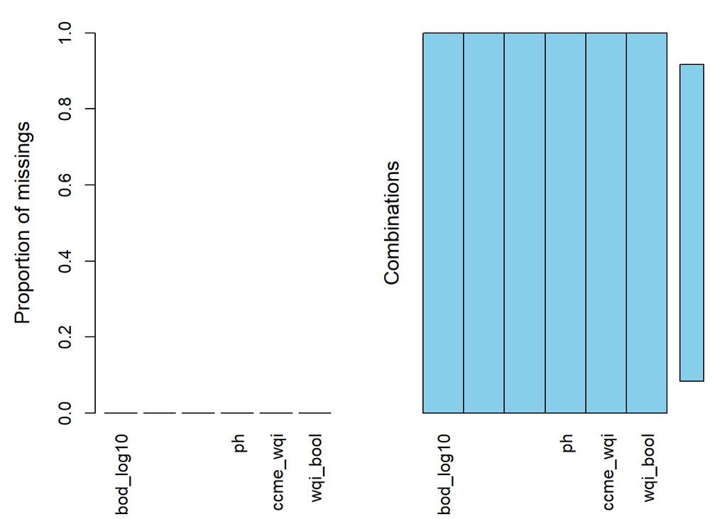

```
 Variables sorted by number of missings:
         Variable Count
        bod_log10     0
 dissolved.oxygen     0
      temperature     0
               ph     0
         ccme_wqi     0
         wqi_bool     0
```

```r
# Prepare data for missingness check
#| fig-cap: "Missing Data for outcome and predictor variables "
mdata <- df1 %>% select(bod_log10, dissolved.oxygen, temperature, ph, ccme_wqi, wqi_bool) %>% as.data.frame()

# Reset row names (this fixes the error)
row.names(mdata) <- NULL

# Missing data inspection
VIM::aggr(mdata,sortVar = TRUE, combined = FALSE)
```

There was no missing data from any variable rows, including in either the outcome or predictor. Given the large sample size (n = 29,154), we earlier removed any problematic values, and this approach is unlikely to bias our data, or materially affect the model.

## 2.7 Visualizations of variables

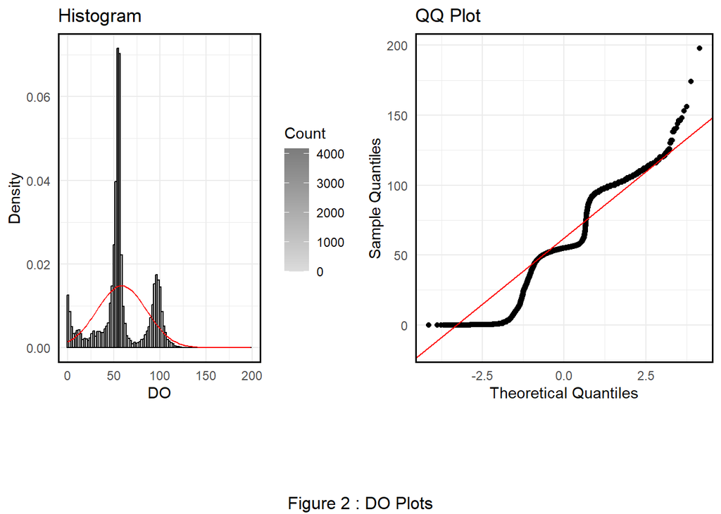

Distribution plots for outcome and predictor variables

```r
# Generate plots using function plot_ratio_variable
lr_t2_df <-df1

# this is called from source file, called at start of thisj .qmd file.
plot_ratio_variable(lr_t2_df, "dissolved.oxygen","DO",2)
```

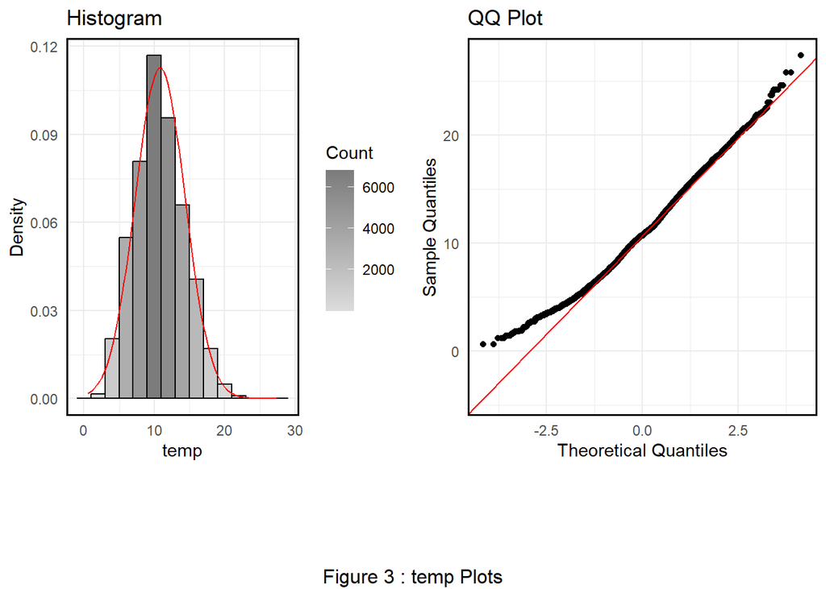

Distribution plots for outcome and predictor variables

```r
plot_ratio_variable(lr_t2_df, "temperature", "temp", 3)
```

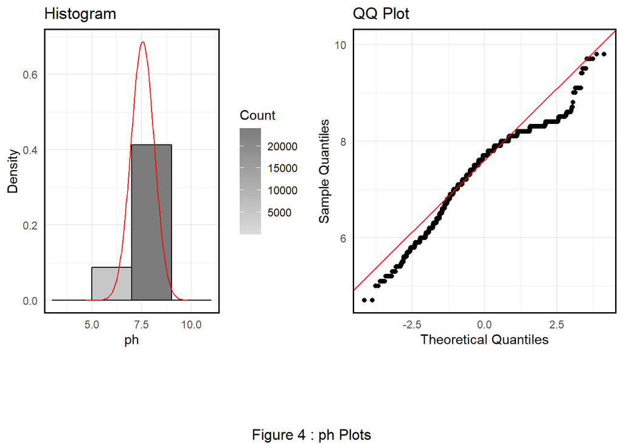

Distribution plots for outcome and predictor variables

```r
plot_ratio_variable(lr_t2_df, "ph", "ph", 4)
```

## 2.8 Final Datset Review

Our final working dataset contains ‘29,154’ rows and ‘6’ variables

# 3. Binary Logistic Regression

## 3.1 Build the model

```r
# Outcome must be 0/1
# craete new df so nto workign in final clean version and can roll back  call that clean initial state as we need.
df_mod <- df1
logmodel1 <- glm(wqi_bool ~ dissolved.oxygen+temperature+ph, data =df_mod, na.action = na.exclude, family = binomial(link=logit))
```

## 3.2 Generate Summary Statisics to Assess model fit

### 3.2a - Summary of Model

This includes all information needed about the model but requires some calculation and additional information to fully assess the fit and usefulness. Additional tests will provide easier access to some parts, we will use elements of this when looking at the odds ratios.

```r
#Full summary of the model
summary(logmodel1)
```

```
Call:
glm(formula = wqi_bool ~ dissolved.oxygen + temperature + ph,
    family = binomial(link = logit), data = df_mod, na.action = na.exclude)

Coefficients:
                   Estimate Std. Error z value Pr(>|z|)
(Intercept)       4.4473926  0.2167356  20.520  < 2e-16 ***
dissolved.oxygen -0.0521261  0.0009009 -57.862  < 2e-16 ***
temperature       0.0266995  0.0055584   4.803 1.56e-06 ***
ph               -0.5031583  0.0308470 -16.311  < 2e-16 ***
---
Signif. codes:  0 '***' 0.001 '**' 0.01 '*' 0.05 '.' 0.1 ' ' 1

(Dispersion parameter for binomial family taken to be 1)

    Null deviance: 27556  on 29153  degrees of freedom
Residual deviance: 20427  on 29150  degrees of freedom
AIC: 20435

Number of Fisher Scoring iterations: 5
```

### 3.2b - Omnibus Test of Model

Tells us whether the model as a whole is significant. Gives us the Chi Square statistic to report for the model as a whole.

```r
#Chi-square plus significance
lmtest::lrtest(logmodel1)
```

```
Likelihood ratio test

Model 1: wqi_bool ~ dissolved.oxygen + temperature + ph
Model 2: wqi_bool ~ 1
  #Df LogLik Df  Chisq Pr(>Chisq)
1   4 -10213
2   1 -13778 -3 7129.9  < 2.2e-16 ***
---
Signif. codes:  0 '***' 0.001 '**' 0.01 '*' 0.05 '.' 0.1 ' ' 1
```

### 3.2c - Use Stargazer to Report

```r
#Summary of the model with co-efficients
stargazer(logmodel1, type="text", star.cutoffs = c(0.05, 0.01, 0.001))
```

```
===============================================
                       Dependent variable:
                  -----------------------------
                            wqi_bool
-----------------------------------------------
dissolved.oxygen            -0.052***
                             (0.001)

temperature                 0.027***
                             (0.006)

ph                          -0.503***
                             (0.031)

Constant                    4.447***
                             (0.217)

-----------------------------------------------
Observations                 29,154
Log Likelihood             -10,213.310
Akaike Inf. Crit.          20,434.610
===============================================
Note:             *p<0.05; **p<0.01; ***p<0.001
```

### 3.2d - Pseudo R2 Statistics

Pseudo R2 statistics tell us how much better does the model fit the data compared to a baseline model (a model with no predictors)?

```r
#Pseudo R Squared
DescTools::PseudoR2(logmodel1, which="CoxSnell")
```

```
 CoxSnell
0.2169502
```

```r
DescTools::PseudoR2(logmodel1, which="Nagelkerke")
```

```
Nagelkerke
 0.3548418
```

```r
performance::r2(logmodel1) # Will return Tujur's Pseudo R2
```

```
# R2 for Logistic Regression
  Tjur's R2: 0.271
```

### 3.2d Report

A binary logistic regression model was fitted to predict the probability of good water quality (wqi_bool = 1), using the predictor variables **dissolved.oxygen(DO)**, **temperature** and **ph**.

The binary logistic regression equation is therefore:

Log(𝑝/1-𝑝)=𝛽0+𝛽1𝐷1+𝛽2𝐷2

which becomes:

Log (P / 1 - P) = 4.45 + (-0.052 x (DO)) + (0.026 x (Temperature)) + (-0.503 x (ph))

- where p is the probability of good water quality i.e. **wqi_bool** = 1

The intercept values of (b co-eff = 4.45, p < 0.001), representing the baseline log odds of good water quality outcome, when all predictors are equal to zero. It is statistically significant (p < 0.001).

The predictors had the following values:

-**DO**: Is a statistically significant negative predictor (b co-eff = -0.052, p <0.001) and for every 1 unit *increase* in **DO** the log odds of good water quality *decreases* by 0.052. The negative sign indicating that a higher **DO** value is is associated with lower probability of the outcome being good water quality, or ‘1’ -**temperature**: Is a statistically significant positive predictor (b co-eff = 0.026, p <0.001). The positive sign indicating that a higher **Temperature** value is is associated with higher probability of the outcome being good water quality, or ‘1’ - **ph**: Is a statistically significant negative predictor (b co-eff = -0.503, p <0.001). The negative sign indicating that every 1 unit *increase* in **ph** value the log odds of the outcome being good water quality, or ‘1’ *decrease* by 0.503

We will transform the log odds values to odds ratios later for further analysis.

We note AIC: 20435, providing reference for model fit, however we will not be performing a comparative model analysis.

We also note the Null deviance value of ‘27,556’, which is our baseline value using only the intercept i.e. no predictors, and that the residual deviance of ‘20427’ is significantly less than this when predictors are included. This indicated the predictors have significantly improved the model compared to just random chance.

The likelihood ratio test evaluated our model by comparing the fitted model against a null model (chi-squared = 7129.9, p < 0.001) indicates that the inclusion of our predictors, **DO**, **temperature** and **ph** significantly improved the model fit compared to a null model.

Pseudo R squared metrics to further evaluate the model fit resulted in values (Nagelkerke R2 = 0.354, Coxsnell = 0.21 and Tjur’s R2 = 0.27) suggesting that the model explains approx 35% of the variation in water quality, and the Tjur’s R2 = 0.27 indicates sufficient separation between the classification categories of ‘good’ and ‘poor’ water, with the Coxsnell value re-inforcing earlier analysis of the predictor model being significantly better than random chance, or a null model. We also not that a corollary of the Nagelkerkes 0.35 value is that 65% of data data influencing water quality is not present in our dataset.

# 4. Calculate Odds Ratios and Probability of Co-efficients

```r
# Odds ratios only
parameters::parameters(logmodel1, exponentiate = TRUE) %>%
  as.data.frame() %>%
  dplyr::select(Parameter, OddsRatio = Coefficient)
```

```
Profiled confidence intervals may take longer time to compute.
  Use `ci_method="wald"` for faster computation of CIs.
```

```
         Parameter  OddsRatio
1      (Intercept) 85.4039689
2 dissolved.oxygen  0.9492091
3      temperature  1.0270591
4               ph  0.6046181
```

```r
# Predicted probabilities by pred1
emmeans::emmeans(logmodel1, ~ dissolved.oxygen, type = "response")
```

```
 dissolved.oxygen  prob      SE  df asymp.LCL asymp.UCL
             58.3 0.109 0.00217 Inf     0.105     0.113

Confidence level used: 0.95
Intervals are back-transformed from the logit scale
```

```r
# Predicted probabilities by pred2
emmeans::emmeans(logmodel1, ~ temperature, type = "response")
```

```
 temperature  prob      SE  df asymp.LCL asymp.UCL
        10.8 0.109 0.00217 Inf     0.105     0.113

Confidence level used: 0.95
Intervals are back-transformed from the logit scale
```

```r
# Predicted probabilities by pred3
emmeans::emmeans(logmodel1, ~ ph, type = "response")
```

```
   ph  prob      SE  df asymp.LCL asymp.UCL
 7.55 0.109 0.00217 Inf     0.105     0.113

Confidence level used: 0.95
Intervals are back-transformed from the logit scale
```

```r
# Predicted probabilities by pred4
#emmeans::emmeans(logmodel1, ~ bod_log10, type = "response")



pred_grid <- emmeans::emmeans(
  logmodel1,
  ~ dissolved.oxygen+temperature+ph,   # <-- interaction in predictions, even if not in model
  type = "response"
)

summary(pred_grid)
```

```
 dissolved.oxygen temperature   ph  prob      SE  df asymp.LCL asymp.UCL
             58.3        10.8 7.55 0.109 0.00217 Inf     0.105     0.113

Confidence level used: 0.95
Intervals are back-transformed from the logit scale
```

**Odds Ratio**

For odds we look to see if ratio greater than 1 or less than 1?

OR > 1 → higher odds of getting good water quality outcome of ‘1’.

OR < 1 → lower odds of getting good water quality outcome of ‘1’.

The Wald statistic is calculated to get the magnitude of the predictor, and the resultant sign will indicate direction of the effect.

- **DO**
  - Is statistically significant (OR = 0.949, p <0.001) As OR is < 1, implies ‘increased’ **DO** values are associated with ‘decreased’ odds of getting target outcome i.e. good water quality. Therefor as (1 - 0.949 = 0.051) for one unit increase in **DO** we get a 5.1% decrease in odds of a getting a good water quality outcome.
- **Temperature**
  - Is statistically significant (OR = 1.027, p <0.001) As OR is > 1, implies ‘increased’ **Temperature** values are associated with ‘increased’ odds of getting target outcome i.e. good water quality. Therefor as (1 - 1.027 = 0.027) for one unit (degree celsius) increase in **Temperature** we get a 2.7% increase in odds of a getting a good water quality outcome.
- **ph**
  - Is statistically significant (OR = 0.604, p <0.001) As OR is < 1, implies ‘increased’ **ph** values are associated with ‘decreased’ odds of getting target outcome i.e. good water quality. Therefor as (1 - 0.604 = 0.395) for one unit increase in **ph** we get a 39.6% decrease in odds of a getting a good water quality outcome. This is the most significant predictor with a change in unit value providing the greatest impact on outcome.

**Predicted Probabilities**

give us the calculated predicted probabilities for each combination of the predictors. With values of (**DO** = 58.3, **Temperature** = 10.8 , **ph** = 7.55) and a predicted probability (prob = 0.109 = 10.9%) for the water quality to be classified as good. This is the probability of obtaining the outcome state under average conditions in our data.

# 5. Assess Classification Performance

## 5.1 Generate a ROC curve and Calculate Sensitivity, Specificity and AUC

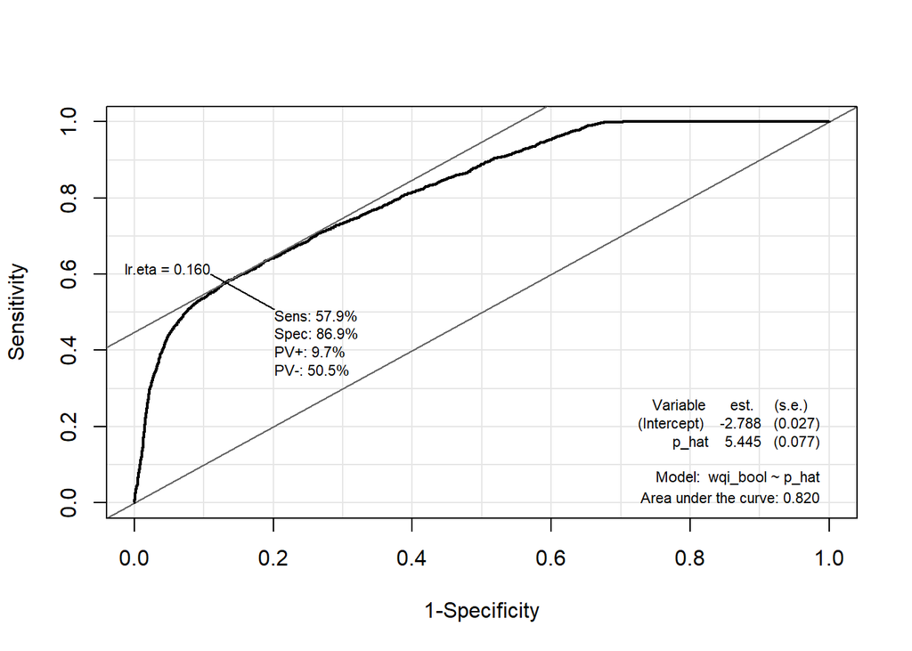

ROC curve for Model1

```r
df_roc <-df1
# Generate predicted probabilities for Model 1
p_hat <- stats::predict(logmodel1, type = "response")

# Build results1 data frame for Epi::ROC
results1 <- df_roc %>%
  dplyr::mutate(
    wqi_bool = wqi_bool,   # already created earlier
    p_hat = p_hat                # predicted probabilities
  ) %>%
  dplyr::select(wqi_bool, p_hat) %>%     # only keep needed columns
  dplyr::filter(!is.na(wqi_bool))        # remove NA cases

# Generate the curve
roc1 <-Epi::ROC(
  form = wqi_bool ~ p_hat,
  data = results1,
  plot = "ROC"
)
```

A ROC curve (Receiver Operating Characteristic curve) was generated as a way of checking how well the model can distinguish between the two outcome groups:

- good water quality (1)
- poor water quality (0)

What does Area Under the Curve (AUC) mean?

- AUC = 0.50 → model performs no better than random guessing
- AUC = 1.00 → perfect prediction
- AUC between 0.5 and 0.7 → poor discrimination
- AUC between 0.7 and 0.8 → acceptable discrimination

In our model AUC = 0.820. The model indicates good discrimination. This suggest that the model is effective at raking data such that good water quality generally receives higher predicted probabilities than those with poor water quality.

## 5.2 Generate a Confusion Matrix

```r
df_cm <- df1
results1 <- df_cm %>%
  dplyr::mutate(
    actual = factor(wqi_bool, levels = c(0,1)),
    pred_class = factor(
      ifelse(stats::predict(logmodel1, type = "response") > 0.5, 1, 0),
      levels = c(0,1)
    )
  )


cm <- yardstick::conf_mat(
  data = results1,
  truth = actual,
  estimate = pred_class
)

cm
```

```
          Truth
Prediction     0     1
         0 22915  3152
         1   968  2119
```

The Confusion Matrix evaluated the models predictive powers by comparing

- Actual values ‘good’ or ‘poor’ water quality vs
- Predicted values i.e. what the model says at a probability cutoff = 0.5

The model predictive results were:

- True Positives (TP) (2,119): predicted good & actually good
- True Negatives (TN) (22,915): predicted poor & actually poor
- False Positives (FP) (968): predicted good but actually poor
- False Negatives (FN) (3,152): predicted poor but actually good

**Sensitivity**

Sensitivity measures how well the model identifies the category of interest (1) cases: Of all the rows with the value 1, how many did the model correctly identify?

- Calculation : Sensitivity = True Positives / (True Positives + False Negatives)
- 2119/(2119+3152) = 40.2%

The model has relatively low sensitivity, meaning it only correctly identifies about 40% of real ‘good’ water quality cases, meaning it misses approx 60% of the target outcomes. This is a a cautious model.

**Specificity**

Specificity measures how well the model identifies the rows with 0: how many did the model correctly identify as 0? High specificity means the model is good at detecting cases with 0. Low specificity means the model predicts 1 too often.

- Calculation : Specificity = True Negative / (True Negative + False Positive)
- 22,915/(22,915+968) = 95.9%

The model has high specificity, meaning it correctly identified >95% of real ‘poor’ water quality cases.

Overall the model is good at identifying ‘poor’ quality water data, and this primarily driving the model accuracy. However it is not great at identifying our desired outcome of ‘good’ water quality. The model does not take risks identifying good water quality. However, of concern in real world scenarios would be where the water is ‘poor’ quality but we incorrectly identify it as ‘good’, with potential health or environmental impacts. Therefore the low sensitivity may suit our usage scenario.

We also note that while we had statistical significance in earlier analysis, this does not necessarily translate to accuracy to predict the desired target outcome.

# 6. Check Model Meets Assumptions of Logistic Regression

## 6.1 Linearity of Independent Variables and Log Odds

```r
#Check the assumption of linearity of independent variables and log odds using a Hosmer-Lemeshow test, if this is not statistically significant we are ok
df_assum <-df1
generalhoslem::logitgof(df_assum$wqi_bool, fitted(logmodel1))
```

```
    Hosmer and Lemeshow test (binary model)

data:  df_assum$wqi_bool, fitted(logmodel1)
X-squared = 144.77, df = 8, p-value < 2.2e-16
```

The Hosmer-Lemeshow test calculated values of (chi-squared = 144.77, df = 8, p < 0.001), is statistically significant, suggesting that there is difference between our observed water quality outcomes and what the model predicts. So we do not meet the requirement in this result for one of our model assumptions.

However, this may re-inforce earlier findings we have from Nagelkerke R2, that a significant portion of data is not accounted for in determining water quality i.e. 65% of the variance is not present in our data to determine ‘good’ or ‘poor’ water quality, or also that the relationship between he model and the data is more complex than our model can accommodate at present. Unfortunately this is beyond the scope of the project at this time due time constraints, and we note it for future investigation

## 6.2 Collinearity

```r
#We would check for collinearity here but as we only have one predictor it doesn't make sense - check model 2 to see how to do this

## 4.7 Check multi-colinearity

#| label: res_multicollin
# Check multicollinearity

performance::check_collinearity(logmodel1)
```

```
# Check for Multicollinearity

Low Correlation

             Term  VIF   VIF 95% CI adj. VIF Tolerance Tolerance 95% CI
 dissolved.oxygen 1.12 [1.11, 1.14]     1.06      0.89     [0.88, 0.90]
      temperature 1.03 [1.02, 1.04]     1.01      0.98     [0.96, 0.98]
               ph 1.15 [1.13, 1.16]     1.07      0.87     [0.86, 0.88]
```

The data met the assumption for independent observations. Examination for multicollinearity showed that the tolerance and variance influence factor measures for our predictor variables were within acceptable levels (tolerance >0.4, VIF <2.5 ) as outlined in Tarling (2008).

## 6.3 Outliers and Influential Cases

Although logistic regression does not require the residuals to be normally distributed, it is still important to check for outliers and influential cases. Individual observations with unusually large residuals, high leverage, or strong influence can distort coefficient estimates, odds ratios, and overall model fit. Minimal diagnostic checks—such as Cook’s Distance, leverage values, standardised residuals, and DFBetas—help identify whether any single case is exerting undue influence on the model. These checks do not require the removal of observations but allow us to confirm that the results are not being driven by a small number of extreme or unusual cases. - **Cook’s Distance**: Measures how much each individual observation influences the overall model; large values indicate cases that may disproportionately affect the results.

- **Leverage (Hat values)**: Identifies observations with unusual predictor values; high-leverage cases have the potential to pull the model toward themselves.
- **Standardised (Pearson) residuals**: Show how poorly each observation is predicted by the model; large residuals (e.g., > |2|) indicate unusual or poorly fitted cases.
- **Deviance residuals**: Reflect how much each observation contributes to the model’s deviance; large values highlight observations the model struggles to accurately classify.
- **DFBetas**: Measure how much each observation influences individual regression coefficients; large DFBetas indicate that removing the case would substantially change a coefficient estimate.

```r
# 1. Cook's Distance
cook <- cooks.distance(logmodel1)

# View largest Cook's D values
head(sort(cook, decreasing = TRUE))

# Flag influential cases (common threshold: D > 1)
length(which(cook > 1))


# 2. Leverage (Hat values)
lev <- hatvalues(logmodel1)

# View highest leverage cases
head(sort(lev, decreasing = TRUE))

# Flag high leverage cases
# Rule of thumb: h_i > 2*(k+1)/n
k <- length(coef(logmodel1)) - 1  # number of predictors
n <- nobs(logmodel1)
lev_threshold <- 2*(k+1)/n
length(which(lev > lev_threshold))


# 3. DFBetas (influence on individual coefficients)
dfb <- dfbeta(logmodel1)

# Identify cases with large DFBetas (|DFB| > 1 is concerning)
which(abs(dfb) > 1, arr.ind = TRUE)


# 4. Standardised (Pearson) residuals
pearson_resid <- rstandard(logmodel1, type = "pearson")

# Flag large residuals (|residual| > 2 or > 3)
length(which(abs(pearson_resid) > 2))

# Optional: look at the largest ones
head(sort(abs(pearson_resid), decreasing = TRUE))


# 5. Deviance residuals
dev_resid <- residuals(logmodel1, type = "deviance")

# Flag extreme deviance residuals
length(which(abs(dev_resid) > 2))
```

[output not shown]

Checks for model estimates being unduly influenced by a small number of outliers was conducted, with the results as follows.

**Cooks Distance** - maximum value for cooks distance is 0.001, which is below the threshold value of 1, confirming no observation is unduly influencing overall model co-efficients.

**Leverage (Hat Values)** - There are 4062 values above the threshold value of i > 2*(k+1)/n. however as we have a very large data set, (n=29,154) and cook’s distance values was not exceeded by any values, we can conclude that these values are not harming the model performance. This would require further investigation however, which we are unable to do at this time.

**DFBeta** - To assess the individual observations on specific regression co-efficients. - There is one case that is influential, row 2309, exceeding + or - 1. - This could be a specific issue with one row of data, and not materially affecting the model performance. - his observation did nit exceed Cooks distance, as such we will not consider this sufficiently influential to delete at thss stage. - This would require further investigation however.

**Standadtised and Deviance residuals** - There are 1198 values with standardized residuals were significantly far from the actual result, i.e. were difficult to classify. - This number is when the threshold > 2. we could modify this to a larger value of 3, given our large dataset, however the existing threshold values do not invalidate the model performance. - Again however given our large data set the proportion does not imply systemic issue. - This would warrant further investigation.

Overall, while some cases appear initially problematic, so single valeu or subset of data disproportionately affects the overall model performnace.

# 7. Report

A binary logistic regression was conducted to predict water quality status (good vs poor). The analysis was based on a sample of 29,154 rows. The outcome variable was coded 0 = poor water quality and 1 = good water quality. The predictors were dissolved oxygen (% saturation), temperature (°C), and pH, all measured as continuous variables.

For example, increases in dissolved oxygen and pH were associated with lower odds of good water quality, while higher temperatures were associated with increased odds, holding other variables constant.

Predicted probabilities followed a similar pattern:

At average conditions (dissolved oxygen = 58.3, temperature = 10.8°C, pH = 7.55), the predicted probability of good water quality was 0.109 (95% CI: 0.105–0.113).

These results show that even under average environmental conditions, the probability of good water quality remains relatively low, reflecting the conservative nature of the model.

The model’s predictive performance was evaluated using a ROC curve and confusion matrix. The AUC was 0.820, indicating good discrimination. Using a 0.5 classification threshold, the model predicted poor water quality substantially more accurately than good water quality. This led to:

Low sensitivity (40.2%, meaning the model correctly identifies only about 40% of truly good water quality cases), and

High specificity (95.9%, meaning the model correctly identifies over 95% of poor water quality cases).

This imbalance suggests the model is conservative, prioritising avoidance of false classification of poor water as good, which may be appropriate in environmental and public health contexts.

The Hosmer–Lemeshow goodness-of-fit test indicate concerns with linearity. Multicollinearity was not an issue (all VIF values were below common thresholds). Influence diagnostics were examined to ensure that the logistic regression results were not affected by individual cases.

To assess the presence of influential data points, Cook’s Distance values were all extremely small, with a maximum of D ≈ 0.001, which is well below the conventional influence threshold of 1. This suggests that no single observation exerted unusual influence on the model.

Leverage values were variable, indicating that some cases had unusual combinations of predictor values (maximum leverage ≈ 0.0024).

Standardised Pearson residuals and deviance residuals ranged from near 0 to greater than ±2, meaning that some observations exceeded the common cutoff of ±2, and therefore some unusual outcome patterns were detected.

Inspection of DFBETAs revealed one instance in which the removal of a case would substantially alter a regression coefficient (maximum |DFBETA| > 1).

Taken together, these diagnostics indicate that the results of this logistic regression model are generally stable and not driven by a small number of influential points but may be somewhat sensitive to a small number of unusual observations and should be interpreted with caution.

Overall, the model is robust despite the identification of individual outliers.